# Cort models eval

## Objectives

1. New responses:
- s2 - s1: absolute change
- (s2-s1)/s1: proportional change
1. Do responses satisfy normality?
2. Produce one model with max and one model with min, look at graphically to see what looks nicest
3. Evaluate model:
- fit
- qqplots
- outliers
- residuals vs temp

## Do responses satisfy normality?

## WEBL

### Baseline cort

May be basically okay but a transformation may help.

### Square root transformation

This looks like enough for cort_s1.

### Absolute difference cort_s2-cort_s1

Not great! Needs to be transformed!

### Square root transformation

Closer… Maybe try natural log?

### Natural log

Too far! Looks like sqrt is the best transformation.

### Proportional difference (cort_s2-cort_s1)/cort_s1

Needs to be transformed.

### Square root transformation

Not quite enough… maybe the natural log? But this does look better.

### Natural log

Too far, looks like the square root transformation is the one for all three responses for WEBL.

### Conclusions

Square root transformation for all three cort response variables helps with normality of response variable.

## TRES

### Baseline cort

May be basically okay but a transformation may help.

### Square root transformation

This looks like enough for cort_s1.

### Absolute difference cort_s2-cort_s1

Honestly looks mostly okay to me.

### Square root transformation

That’s enough for abs change!

### Proportional difference (cort_s2-cort_s1)/cort_s1

Needs to be transformed.

### Square root transformation

Honestly looks pretty much good. Will try the natural log just in case.

### Natural log

Too far, looks like the square root transformation is the one for all three responses for TRES.

### Conclusions

Square root transformation for all three cort response variables helps with normality of response variable.

## For each response, produce 2 models:

1. linear max and min
2. Squared max

## WEBL

### sqrt(cort_s1)

#### What happens to VIFs for linear model without interactions?

This should tell us whether max and min are worryingly collinear with each other.

### sqrt(abs_change_cort)

#### Plots

This response seems a little bit rough in the model dept. Tough to tell what exactly is going on.

#### Plots

This response seems a little bit rough in the model dept. Tough to tell what exactly is going on.

### Conclusions:

I like sqrt(cort_s1) as a response better than the others. There seems to be more signal there, and it’s the most normal response.

Revisiting those two models, I think an argument could be made for either. The VIFs are inflated by the interaction terms for both models, and when I run the linear model without the max * habitat interaction, its VIF is under the threshold.

I like the idea of parsing out the effect of max temp from min temp, could be a useful comparison to make with previous work looking at the cort effects of cold. This is something I’d like to bring up in lab meeting - maybe crowdsource some thoughts about what those two models tell us.

## TRES

### sqrt(cort_s1)

#### Plots

```
Model has sqrt-transformed response. Back-transforming predictions to original response scale. Standard errors are still
  on the transformed scale.
Data points may overlap. Use the `jitter` argument to add some amount of random variation to the location of data points
  and avoid overplotting.
```

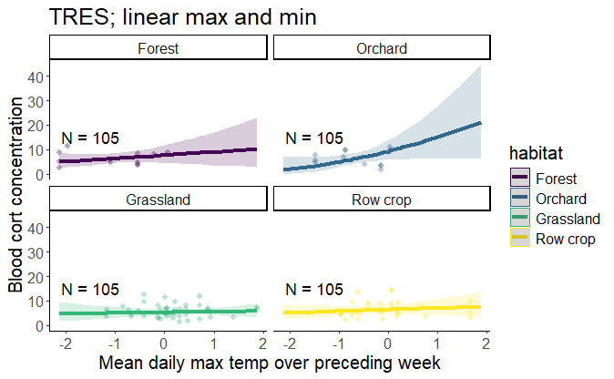

```
Linear mixed model fit by REML. t-tests use Satterthwaite's method ['lmerModLmerTest']
Formula: sqrt(cort_s1) ~ meanmaxtempI_scaled * habitat + meanmintempI_scaled *
    habitat + age_scaled + juliandate_scaled + year_fct + (1 |      attempt_id)
   Data: dplyr::filter(g, Species == "TRES", !is.na(meanmaxtempI), !is.na(meanmintempI)) %>%
    mutate(across(c(gweight, meanmaxtempI, meanmintempI, juliandate,
        brood_size, age), ~scale(.x)[, 1], .names = "{.col}_scaled"),
        meanmaxtempI_scaled_sq = meanmaxtempI_scaled * meanmaxtempI_scaled)

REML criterion at convergence: 190.3

Scaled residuals:
     Min       1Q   Median       3Q      Max
-1.97197 -0.59931 -0.04445  0.56632  2.10587

Random effects:
 Groups     Name        Variance Std.Dev.
 attempt_id (Intercept) 0.02699  0.1643
 Residual               0.28859  0.5372
Number of obs: 105, groups:  attempt_id, 41

Fixed effects:
                                     Estimate Std. Error       df t value Pr(>|t|)
(Intercept)                           2.86437    0.36738 53.79672   7.797 2.15e-10 ***
meanmaxtempI_scaled                   0.25180    0.26057 36.00984   0.966  0.34032
habitatOrchard                       -0.01401    0.45870 41.90127  -0.031  0.97578
habitatGrassland                     -0.57198    0.37114 50.96682  -1.541  0.12947
habitatRow crop                      -0.32213    0.41124 43.73650  -0.783  0.43766
meanmintempI_scaled                  -0.53737    0.30022 37.67660  -1.790  0.08150 .
age_scaled                            0.02233    0.07387 52.96052   0.302  0.76363
juliandate_scaled                     0.02554    0.07850 28.14129   0.325  0.74728
year_fct2023                          0.02879    0.16662 24.18324   0.173  0.86427
meanmaxtempI_scaled:habitatOrchard    0.57573    0.48455 27.87866   1.188  0.24479
meanmaxtempI_scaled:habitatGrassland -0.19520    0.30774 37.32213  -0.634  0.52975
meanmaxtempI_scaled:habitatRow crop  -0.12454    0.31613 28.86919  -0.394  0.69652
habitatOrchard:meanmintempI_scaled    1.40521    0.41651 32.71950   3.374  0.00192 **
habitatGrassland:meanmintempI_scaled  0.49012    0.31540 36.12902   1.554  0.12891
habitatRow crop:meanmintempI_scaled   0.39738    0.37747 30.38761   1.053  0.30076
---
Signif. codes:  0 ‘***’ 0.001 ‘**’ 0.01 ‘*’ 0.05 ‘.’ 0.1 ‘ ’ 1
```

```
Correlation matrix not shown by default, as p = 15 > 12.
Use print(x, correlation=TRUE)  or
    vcov(x)        if you need it
```

```
Model has sqrt-transformed response. Back-transforming predictions to original response scale. Standard errors are still
  on the transformed scale.
Data points may overlap. Use the `jitter` argument to add some amount of random variation to the location of data points
  and avoid overplotting.
```

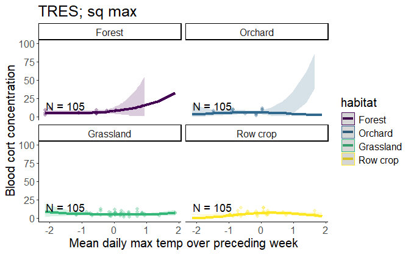

```
Linear mixed model fit by REML. t-tests use Satterthwaite's method ['lmerModLmerTest']
Formula: sqrt(cort_s1) ~ poly(meanmaxtempI_scaled, 2) * habitat + age_scaled +      juliandate_scaled + year_fct + (1 | attempt_id)
   Data: dplyr::filter(g, Species == "TRES", !is.na(meanmaxtempI), !is.na(meanmintempI)) %>%
    mutate(across(c(gweight, meanmaxtempI, meanmintempI, juliandate,
        brood_size, age), ~scale(.x)[, 1], .names = "{.col}_scaled"),
        meanmaxtempI_scaled_sq = meanmaxtempI_scaled * meanmaxtempI_scaled)

REML criterion at convergence: 138.8

Scaled residuals:
     Min       1Q   Median       3Q      Max
-2.09350 -0.60830 -0.03807  0.54821  2.20998

Random effects:
 Groups     Name        Variance Std.Dev.
 attempt_id (Intercept) 0.0594   0.2437
 Residual               0.2865   0.5353
Number of obs: 105, groups:  attempt_id, 41

Fixed effects:
                                                 Estimate Std. Error         df t value Pr(>|t|)
(Intercept)                                     3.089e+00  8.140e-01  5.903e+01   3.795  0.00035 ***
poly(meanmaxtempI_scaled, 2)1                   2.480e+01  3.031e+01  4.649e+01   0.818  0.41747
poly(meanmaxtempI_scaled, 2)2                   1.498e+01  2.067e+01  4.093e+01   0.725  0.47266
habitatOrchard                                 -9.613e-01  1.215e+00  5.929e+01  -0.791  0.43193
habitatGrassland                               -7.682e-01  8.300e-01  5.801e+01  -0.926  0.35851
habitatRow crop                                -9.642e-01  8.349e-01  5.662e+01  -1.155  0.25296
age_scaled                                     -4.663e-02  8.400e-02  5.789e+01  -0.555  0.58093
juliandate_scaled                              -7.108e-04  8.647e-02  3.039e+01  -0.008  0.99350
year_fct2023                                    3.395e-01  1.790e-01  2.621e+01   1.896  0.06900 .
poly(meanmaxtempI_scaled, 2)1:habitatOrchard   -3.172e+01  4.713e+01  6.145e+01  -0.673  0.50354
poly(meanmaxtempI_scaled, 2)2:habitatOrchard   -2.394e+01  3.807e+01  7.310e+01  -0.629  0.53138
poly(meanmaxtempI_scaled, 2)1:habitatGrassland -2.263e+01  3.035e+01  4.677e+01  -0.746  0.45954
poly(meanmaxtempI_scaled, 2)2:habitatGrassland -9.012e+00  2.129e+01  4.239e+01  -0.423  0.67429
poly(meanmaxtempI_scaled, 2)1:habitatRow crop  -2.863e+01  3.035e+01  4.573e+01  -0.944  0.35038
poly(meanmaxtempI_scaled, 2)2:habitatRow crop  -3.574e+01  2.193e+01  3.759e+01  -1.630  0.11145
---
Signif. codes:  0 ‘***’ 0.001 ‘**’ 0.01 ‘*’ 0.05 ‘.’ 0.1 ‘ ’ 1
```

```
Correlation matrix not shown by default, as p = 15 > 12.
Use print(x, correlation=TRUE)  or
    vcov(x)        if you need it
```

```
Failed to compute posterior predictive checks with `re_formula=NULL`.
  Trying again with `re_formula=NA` now.
```

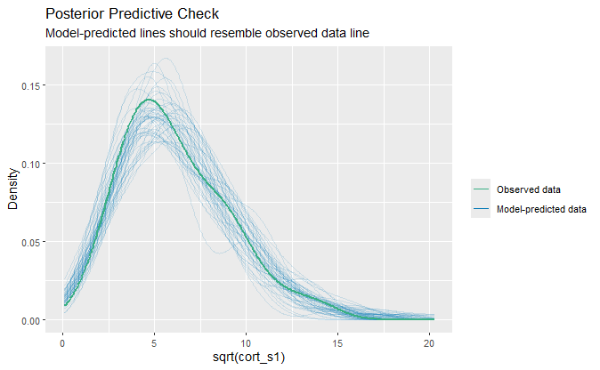

```
Failed to compute posterior predictive checks with `re_formula=NULL`.
  Trying again with `re_formula=NA` now.
```

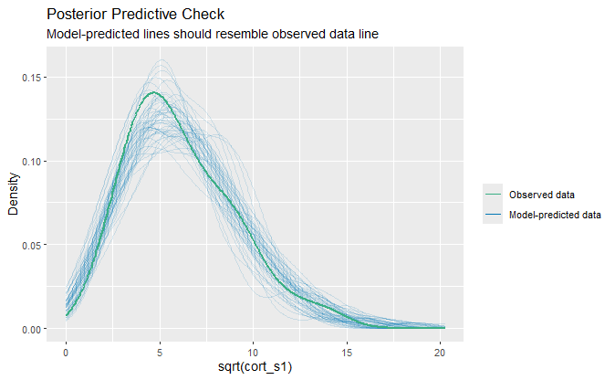

```
Model has interaction terms. VIFs might be inflated.
  Try to center the variables used for the interaction, or check multicollinearity among predictors of a model without
  interaction terms.
```

```
# Check for Multicollinearity

Low Correlation

              Term  VIF       VIF 95% CI Increased SE Tolerance Tolerance 95% CI
        age_scaled 1.23 [  1.08,   1.63]         1.11      0.81     [0.61, 0.92]
 juliandate_scaled 1.92 [  1.56,   2.51]         1.39      0.52     [0.40, 0.64]
          year_fct 1.91 [  1.56,   2.50]         1.38      0.52     [0.40, 0.64]

High Correlation

                        Term    VIF       VIF 95% CI Increased SE Tolerance Tolerance 95% CI
         meanmaxtempI_scaled  12.86 [  9.50,  17.55]         3.59      0.08     [0.06, 0.11]
                     habitat  25.35 [ 18.57,  34.74]         5.03      0.04     [0.03, 0.05]
         meanmintempI_scaled  26.58 [ 19.47,  36.44]         5.16      0.04     [0.03, 0.05]
 meanmaxtempI_scaled:habitat  59.07 [ 43.07,  81.18]         7.69      0.02     [0.01, 0.02]
 habitat:meanmintempI_scaled 172.54 [125.48, 237.39]        13.14  5.80e-03     [0.00, 0.01]
```

```
Model has interaction terms. VIFs might be inflated.
  Try to center the variables used for the interaction, or check multicollinearity among predictors of a model without
  interaction terms.
```

```
# Check for Multicollinearity

Low Correlation

              Term  VIF          VIF 95% CI Increased SE Tolerance Tolerance 95% CI
        age_scaled 1.36 [   1.17,     1.77]         1.17      0.74     [0.56, 0.86]
 juliandate_scaled 1.87 [   1.53,     2.44]         1.37      0.53     [0.41, 0.66]
          year_fct 1.76 [   1.45,     2.29]         1.33      0.57     [0.44, 0.69]

High Correlation

                                 Term      VIF          VIF 95% CI Increased SE Tolerance Tolerance 95% CI
         poly(meanmaxtempI_scaled, 2)   566.95 [ 411.96,   780.39]        23.81  1.76e-03     [0.00, 0.00]
                              habitat   578.92 [ 420.65,   796.87]        24.06  1.73e-03     [0.00, 0.00]
 poly(meanmaxtempI_scaled, 2):habitat 13666.38 [9926.64, 18815.15]       116.90  7.32e-05     [0.00, 0.00]
```

#### What happens to VIFs for without interactions?

This should tell us whether max and min are worryingly collinear with each other.

```
boundary (singular) fit: see help('isSingular')
Model has interaction terms. VIFs might be inflated.
  Try to center the variables used for the interaction, or check multicollinearity among predictors of a model without
  interaction terms.
```

```
# Check for Multicollinearity

Low Correlation

                Term  VIF     VIF 95% CI Increased SE Tolerance Tolerance 95% CI
 meanmaxtempI_scaled 2.50 [ 1.96,  3.34]         1.58      0.40     [0.30, 0.51]
             habitat 3.77 [ 2.87,  5.11]         1.94      0.27     [0.20, 0.35]
          age_scaled 1.16 [ 1.04,  1.64]         1.08      0.86     [0.61, 0.96]
   juliandate_scaled 1.63 [ 1.35,  2.15]         1.28      0.61     [0.47, 0.74]

High Correlation

                        Term   VIF     VIF 95% CI Increased SE Tolerance Tolerance 95% CI
         meanmintempI_scaled 21.03 [15.22, 29.21]         4.59      0.05     [0.03, 0.07]
 habitat:meanmintempI_scaled 46.75 [33.63, 65.13]         6.84      0.02     [0.02, 0.03]
```

```
# Check for Multicollinearity

Low Correlation

                         Term  VIF   VIF 95% CI Increased SE Tolerance Tolerance 95% CI
 poly(meanmaxtempI_scaled, 2) 2.50 [1.95, 3.37]         1.58      0.40     [0.30, 0.51]
                      habitat 1.72 [1.40, 2.28]         1.31      0.58     [0.44, 0.71]
                   age_scaled 1.20 [1.06, 1.66]         1.10      0.83     [0.60, 0.94]
            juliandate_scaled 1.76 [1.43, 2.34]         1.33      0.57     [0.43, 0.70]
                     year_fct 1.52 [1.27, 2.02]         1.23      0.66     [0.50, 0.79]
```

### sqrt(abs_change_cort)

#### Plots

```
Model has sqrt-transformed response. Back-transforming predictions to original response scale. Standard errors are still
  on the transformed scale.
Data points may overlap. Use the `jitter` argument to add some amount of random variation to the location of data points
  and avoid overplotting.
```

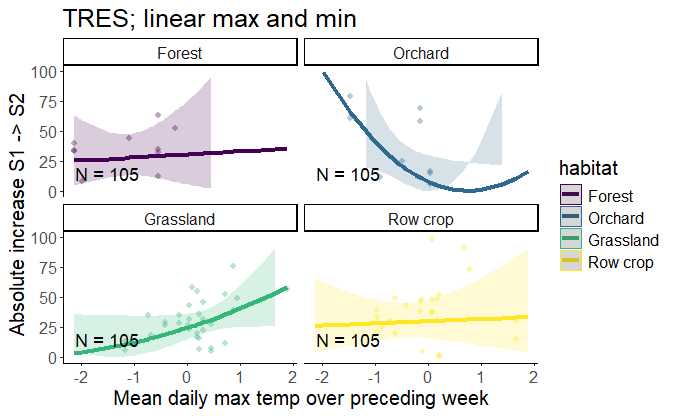

```
Model has sqrt-transformed response. Back-transforming predictions to original response scale. Standard errors are still
  on the transformed scale.
Data points may overlap. Use the `jitter` argument to add some amount of random variation to the location of data points
  and avoid overplotting.
```

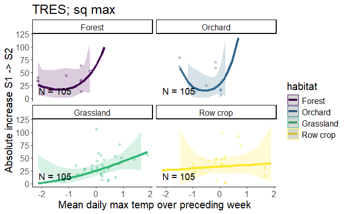

I feel like there’s just not enough data in forest and orchard to model those. I wonder if filtering to just grassland and row crop would help here.

```
Failed to compute posterior predictive checks with `re_formula=NULL`.
  Trying again with `re_formula=NA` now.
```

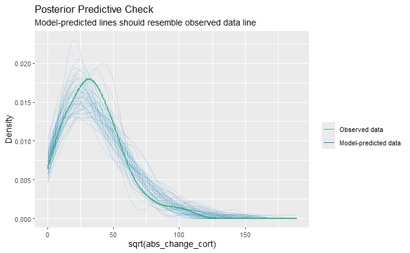

```
Failed to compute posterior predictive checks with `re_formula=NULL`.
  Trying again with `re_formula=NA` now.
```

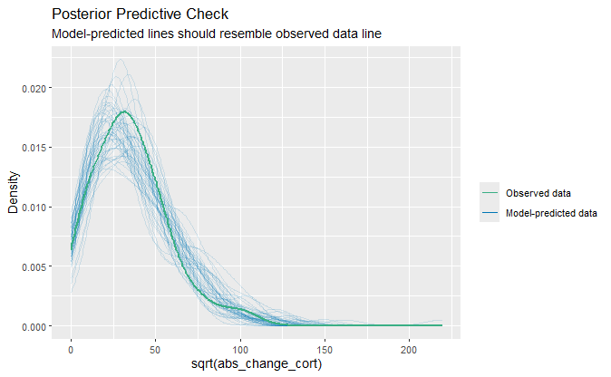

```
Model has interaction terms. VIFs might be inflated.
  Try to center the variables used for the interaction, or check multicollinearity among predictors of a model without
  interaction terms.
```

```
# Check for Multicollinearity

Low Correlation

              Term  VIF      VIF 95% CI Increased SE Tolerance Tolerance 95% CI
        age_scaled 1.54 [ 1.28,   2.05]         1.24      0.65     [0.49, 0.78]
 juliandate_scaled 2.17 [ 1.72,   2.92]         1.47      0.46     [0.34, 0.58]
          year_fct 1.87 [ 1.51,   2.50]         1.37      0.53     [0.40, 0.66]

High Correlation

                        Term    VIF      VIF 95% CI Increased SE Tolerance Tolerance 95% CI
         meanmaxtempI_scaled  16.48 [11.85,  23.09]         4.06      0.06     [0.04, 0.08]
                     habitat  29.90 [21.36,  42.02]         5.47      0.03     [0.02, 0.05]
         meanmintempI_scaled  21.49 [15.40,  30.16]         4.64      0.05     [0.03, 0.06]
 meanmaxtempI_scaled:habitat  64.24 [45.70,  90.46]         8.01      0.02     [0.01, 0.02]
 habitat:meanmintempI_scaled 138.67 [98.45, 195.48]        11.78  7.21e-03     [0.01, 0.01]
```

```
# Check for Multicollinearity

Low Correlation

                Term  VIF   VIF 95% CI Increased SE Tolerance Tolerance 95% CI
 meanmaxtempI_scaled 2.65 [2.01, 3.70]         1.63      0.38     [0.27, 0.50]
             habitat 1.89 [1.49, 2.60]         1.37      0.53     [0.38, 0.67]
 meanmintempI_scaled 1.62 [1.31, 2.23]         1.27      0.62     [0.45, 0.76]
          age_scaled 1.27 [1.09, 1.79]         1.13      0.79     [0.56, 0.92]
   juliandate_scaled 2.01 [1.58, 2.78]         1.42      0.50     [0.36, 0.63]
            year_fct 1.48 [1.22, 2.04]         1.22      0.67     [0.49, 0.82]
```

```
Model has interaction terms. VIFs might be inflated.
  Try to center the variables used for the interaction, or check multicollinearity among predictors of a model without
  interaction terms.
```

```
# Check for Multicollinearity

Low Correlation

              Term  VIF           VIF 95% CI Increased SE Tolerance Tolerance 95% CI
        age_scaled 2.20 [    1.74,     2.96]         1.48      0.45     [0.34, 0.58]
 juliandate_scaled 2.32 [    1.82,     3.12]         1.52      0.43     [0.32, 0.55]
          year_fct 1.76 [    1.43,     2.34]         1.32      0.57     [0.43, 0.70]

High Correlation

                                 Term      VIF           VIF 95% CI Increased SE Tolerance Tolerance 95% CI
         poly(meanmaxtempI_scaled, 2)  1653.51 [ 1172.10,  2332.80]        40.66  6.05e-04     [0.00, 0.00]
                              habitat  2590.57 [ 1836.26,  3654.92]        50.90  3.86e-04     [0.00, 0.00]
 poly(meanmaxtempI_scaled, 2):habitat 51549.19 [36536.07, 72731.57]       227.04  1.94e-05     [0.00, 0.00]
```

```
# Check for Multicollinearity

Low Correlation

                         Term  VIF   VIF 95% CI Increased SE Tolerance Tolerance 95% CI
 poly(meanmaxtempI_scaled, 2) 3.48 [2.58, 4.89]         1.86      0.29     [0.20, 0.39]
                      habitat 1.98 [1.55, 2.72]         1.41      0.51     [0.37, 0.64]
                   age_scaled 1.64 [1.33, 2.25]         1.28      0.61     [0.44, 0.75]
            juliandate_scaled 2.16 [1.68, 2.99]         1.47      0.46     [0.33, 0.60]
                     year_fct 1.49 [1.23, 2.05]         1.22      0.67     [0.49, 0.81]
```

#### sqrt(prop_change_cort)

```
boundary (singular) fit: see help('isSingular')
```

#### Plots

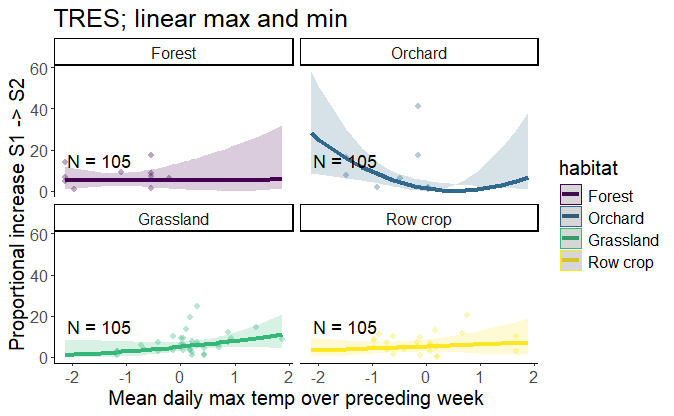

```
Model has sqrt-transformed response. Back-transforming predictions to original response scale. Standard errors are still
  on the transformed scale.
Data points may overlap. Use the `jitter` argument to add some amount of random variation to the location of data points
  and avoid overplotting.
```

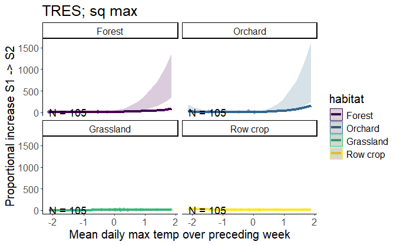

```
Failed to compute posterior predictive checks with `re_formula=NULL`.
  Trying again with `re_formula=NA` now.
```

[figure not shown]

```
Failed to compute posterior predictive checks with `re_formula=NULL`.
  Trying again with `re_formula=NA` now.
```

[figure not shown]

```
# Check for Multicollinearity

Low Correlation

                Term  VIF   VIF 95% CI Increased SE Tolerance Tolerance 95% CI
 meanmaxtempI_scaled 2.65 [2.01, 3.70]         1.63      0.38     [0.27, 0.50]
             habitat 1.89 [1.49, 2.60]         1.37      0.53     [0.38, 0.67]
 meanmintempI_scaled 1.62 [1.31, 2.23]         1.27      0.62     [0.45, 0.76]
          age_scaled 1.27 [1.09, 1.79]         1.13      0.79     [0.56, 0.92]
   juliandate_scaled 2.01 [1.58, 2.78]         1.42      0.50     [0.36, 0.63]
            year_fct 1.48 [1.22, 2.04]         1.22      0.67     [0.49, 0.82]
```

```
# Check for Multicollinearity

Low Correlation

                         Term  VIF   VIF 95% CI Increased SE Tolerance Tolerance 95% CI
 poly(meanmaxtempI_scaled, 2) 3.48 [2.58, 4.89]         1.86      0.29     [0.20, 0.39]
                      habitat 1.98 [1.55, 2.72]         1.41      0.51     [0.37, 0.64]
                   age_scaled 1.64 [1.33, 2.25]         1.28      0.61     [0.44, 0.75]
            juliandate_scaled 2.16 [1.68, 2.99]         1.47      0.46     [0.33, 0.60]
                     year_fct 1.49 [1.23, 2.05]         1.22      0.67     [0.49, 0.81]
```

This response seems a little bit rough in the model dept. Tough to tell what exactly is going on, but again I do like the simplicity of the linear model.

### Conclusions:

For TRES, I like both cort_s1 and absolute increase. prop increase has a singular fit and looks sketchier when graphed. Could consider comparing just grassland and row crop for TRES cort as forest and orchard have very few data points.

I like the idea of parsing out the effect of max temp from min temp, could be a useful comparison to make with previous work looking at the cort effects of cold. This is something I’d like to bring up in lab meeting - maybe crowdsource some thoughts about what those two models tell us.

There might not be much going on (or enough data to identify trends) for TRES cort and temp.